# Introduction to R Syntax

## More (Quick) Plotting

Above, we saw how to create boxplots and histograms with `qplot()`.

You can create a bar plot of count data with `qplot()` as well–below, we make one for correct and incorrect answers (excluding the practice trials):

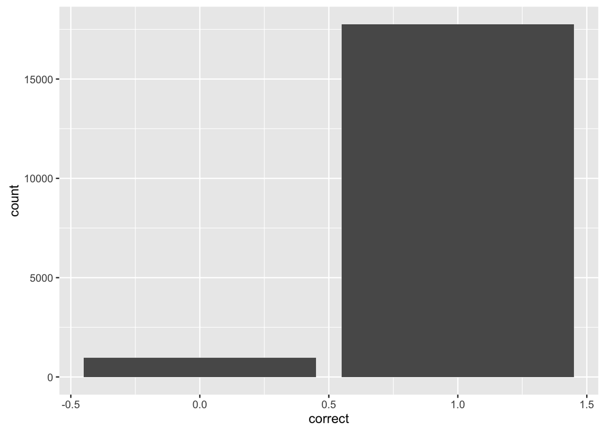

```r
stroop.testtrials <- filter(stroop, exp_stage == "test")
qplot(x = correct, data = stroop.testtrials, geom = "bar")
```

This might be more interesting if we could look at condition differences.

We can `facet` graphs by a grouping variable. Let’s facet the prior graph by `condition`:

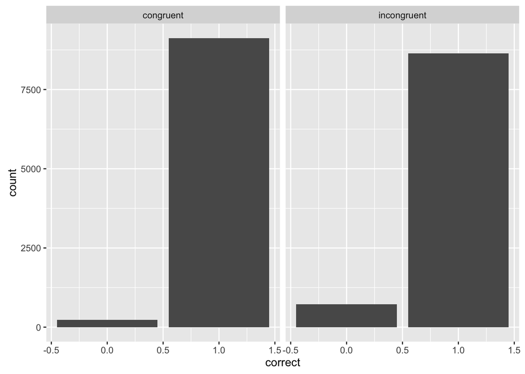

```r
qplot(x = correct, data = stroop.testtrials, geom = "bar", facets = .~condition)
```

(What’s that `.~` about? You can facet by two variables at a time–if you only want one, you put `.` on one side of the `~`.)

Here’s an example of what faceting by two variables looks like:

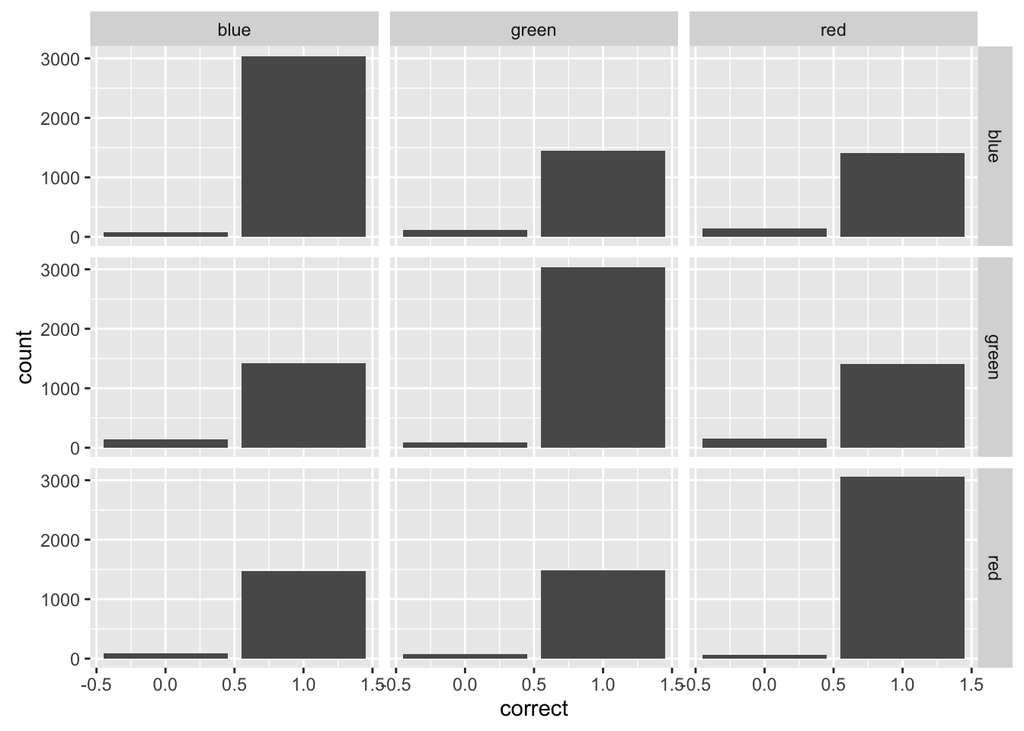

```r
# CHECK YOUR UNDERSTANDING: What's going on here?

qplot(x = correct, data = stroop.testtrials, geom = "bar", facets = stim_color~stim_word)
```

```r
# We've made a bar graph representing the counts of 'correct' and 'incorrect' trials, faceted by both the stimulus color (e.g., the colors Red, Blue, or Green) and the stimulus word (e.g., the words RED, BLUE, and GREEN).

# There are half as many trials in each of the cells representing 'incongruent' pairs compared to 'congruent' pairs. This is  because the study was designed so that overall half of the trials would be 'congruent' and half 'incongruent'.
```

- Here’s a [reference for all of `qplot()`’s options](http://www.statmethods.net/advgraphs/ggplot2.html), with examples.

Soon, though, you’ll need the extra control and flexibility that only `ggplot()` can provide (e.g. for making a bar graph of condition means with error bars).

Tomorrow’s tutorial will begin to introduce `ggplot()`, as well as topics like using functions to perform linear regression and t-tests.

# A few extra resources

- Take a moment to [learn how to write R code with good style](http://adv-r.had.co.nz/Style.html)–that is, code that’s readable and pleasant to look at.
- Check out [dplyr’s documentation](https://cran.rstudio.com/web/packages/dplyr/vignettes/introduction.html) for more info on what you can do with dplyr (and how to do it).
- For a reference guide to [plotting data with ggplot, try the R Cookbook](http://www.cookbook-r.com/Graphs/). Personally, I’ve found the author’s published book, the *R Graphics Cookbook*, particularly helpful.
- For a general reference guide to [using R for data science](http://r4ds.had.co.nz/index.html), i.e. all the sorts of stuff we’ve been doing, look at Grolemund & Wickham’s eponymous [book](http://r4ds.had.co.nz/index.html). (The whole book is online!)
- `tidyr` is a handy package for [reshaping data from wide to long format and back](https://blog.rstudio.org/2014/07/22/introducing-tidyr/).
- `broom` is a handy package for [turning default output from regressions and t-tests into organized data frames](https://github.com/dgrtwo/broom).
- It’s possible (and can be convenient) to [set up a git pane and make commits directly from R.](http://happygitwithr.com/)